# Pengenalan R untuk Pengelolaan dan Visualisasi Data

Webinar Kementerian Kesehatan 03 Agustus 2020 (Studi Kasus COVID-19)

Aep Hidayatuloh

Last Update: 29 July 2020

# Objektif

Mengenalkan R sebagai program analisis data untuk mengelola dan visualisasi data. Pengelolaan dan visualisasi data yang dilakukan diharapkan dapat memperoleh informasi yang dibutuhkan. Pada kesempatan ini akan dibahas membuat visualisasi menggunakan data kasus COVID-19 di berbagai negara dan juga Indonesia. Package yang akan digunakan adalah [tidyverse](https://tidyverse.org/).

# Data & Script

Beberapa hal yang dibutuhkan pada kesempatan ini :

**Program R dan RStudio**, diharapkan minimal R dengan versi 3.6.2 dan beberapa package yang dibutuhkan.

Anda dapat memperoleh materi webinar ini (data, script dan file Rmd) di [repository github](https://github.com/aephidayatuloh/kemenkes-coviz).

- Pilih **Code** (tombol berwarna hijau).
- Kemudian pilih **Download ZIP**.
- Setelah selesai download, ekstrak file zip tersebut dan *double-click* file `kemenkes-coviz.Rproj`.

Atau Anda juga dapat mengakses project tersebut yang sudah tersedia di RStudio Cloud https://rstudio.cloud/project/1492699. Anda perlu login atau membuat akun terlebih dahulu jika belum mempunyai akun RStudio Cloud. Semua materi dan package yang akan digunakan sudah tersedia.

Jika Anda ingin memperbarui data yang sudah disediakan, Anda dapat membuka dan menjalankan script pada file `get_raw_data.R` di dalam folder R. Tentu saja Anda perlu install terlebih dahulu package yang digunakan jika Anda belum mempunyai package tersebut pada library R Anda.

Package tambahan yang dibutuhkan untuk membuat visualisasi pada kesempatan ini adalah {tidyverse}; khususnya {dplyr}, {ggplot2}, dan {scales}. Jika Anda belum menginstall package tersebut, silahkan jalankan perintah berikut. Pastikan Anda mempunyai akses internet yang baik.

```r
install.packages(c("tidyverse", "scales"))
```

Selanjutnya kita dapat menggunakan package tersebut dengan menjalankan

```r
library(tidyverse)
library(scales)
```

Pertama, kita siapkan data yang akan digunakan dengan cara import data dari file CSV yang sudah disediakan di folder `data`. Ada 2 file yang akan digunakan, yaitu `world_covid.csv` dan `dailynational.csv`. Import data tersebut menjadi dataframe bernama `world_covid` menggunakan fungsi `read.csv()` dengan argument `file =` adalah lokasi dan nama file CSV yang akan diimport, `header = TRUE` karena baris pertama adalah nama kolom, dan `stringsAsFactors = FALSE` agar semua kolom bertipe character di file CSV diimport sebagai character, bukan sebagai factor. Untuk lebih jelas tentang factor Anda bisa membaca [dokumentasi factor](https://www.rdocumentation.org/packages/base/versions/3.6.2/topics/factor).

Kemudian kita lihat struktur dari dataframe (banyaknya observasi dan variable, nama variable dan tipenya) yang sudah diimport dengan fungsi `str()`. Data `world_covid` adalah data mengenai banyaknya kasus covid di setiap negara/negara bagian dan populasi penduduknya yang diambil dari https://www.worldometers.info/coronavirus dan https://www.worldometers.info/world-population.

```r
world_covid <- read.csv(file = "../data-raw/world_covid.csv", header = TRUE, stringsAsFactors = FALSE, fileEncoding = "latin1")
str(world_covid)
```

```
## 'data.frame':    209 obs. of  29 variables:
##  $ country            : chr  "USA" "Brazil" "India" "Russia" ...
##  $ total_cases        : int  4371500 2419901 1436019 812485 445433 385036 379884 345790 319501 299426 ...
##  $ new_cases          : int  55791 23467 50525 5765 11233 6751 0 2198 0 745 ...
##  $ total_deaths       : int  149845 87052 32812 13269 6769 43374 18030 9112 28432 45752 ...
##  $ new_deaths         : int  447 556 716 77 114 729 0 92 0 14 ...
##  $ total_recovered    : int  2090129 1634274 918735 600250 265077 247178 263130 318095 0 0 ...
##  $ new_recovered      : int  28437 16794 32500 3110 2023 4486 0 1926 0 0 ...
##  $ active_cases       : int  2131526 698575 484472 198966 173587 94484 98724 18583 0 0 ...
##  $ serious_critical   : int  18986 8318 8944 2300 539 3922 1402 1592 617 104 ...
##  $ tot_cases_1m_pop   : int  13201 11379 1040 5567 7504 2984 11511 18078 6833 4409 ...
##  $ deaths_1m_pop      : int  453 409 24 91 114 336 546 476 608 674 ...
##  $ total_tests        : int  54203902 4911063 16291331 26902291 2773778 911853 2206105 1524533 6320836 14794369 ...
##  $ tests_1m_pop       : int  163689 23093 11797 184339 46729 7067 66847 79703 135187 217848 ...
##  $ population         : chr  "331,139,904" "212,665,350" "1,380,937,553" "145,939,049" ...
##  $ continent          : chr  "North America" "South America" "Asia" "Europe" ...
##  $ x1_caseevery_x_ppl : chr  "76" "88" "962" "180" ...
##  $ x1_deathevery_x_ppl: chr  "2,210" "2,443" "42,086" "10,998" ...
##  $ x1_testevery_x_ppl : chr  "6" "43" "85" "5" ...
##  $ fatality_rate      : num  0.0343 0.036 0.0228 0.0163 0.0152 ...
##  $ population_2020    : int  331002651 212559417 1380004385 145934462 59308690 128932753 32971854 19116201 46754778 67886011 ...
##  $ yearly_change      : num  0.0059 0.0072 0.0099 0.0004 0.0128 0.0106 0.0142 0.0087 0.0004 0.0053 ...
##  $ net_change         : int  1937734 1509890 13586631 62206 750420 1357224 461401 164163 18002 355839 ...
##  $ density_km2        : int  36 25 464 9 49 66 26 26 94 281 ...
##  $ land_area_km2      : num  9147420 8358140 2973190 16376870 1213090 ...
##  $ migrants_net       : int  954806 21200 -532687 182456 145405 -60000 99069 111708 40000 260650 ...
##  $ fert_rate          : num  1.78 1.74 2.24 1.82 2.41 ...
##  $ med_age            : int  38 33 28 40 28 29 31 35 45 40 ...
##  $ urban_pop_percent  : num  0.828 0.876 0.35 0.737 0.667 0.838 0.791 0.848 0.803 0.832 ...
##  $ world_share        : num  0.042 0.027 0.177 0.019 0.008 0.017 0.004 0.002 0.006 0.009 ...
```

Berikutnya kita lihat beberapa baris pertama dari data `world_covid`. Menggunakan fungsi `head()` untuk menampilkan beberapa baris pertama. Dengan `n = 10` artinya menapilkan 10 baris pertama dari data `world_covid`.

```r
head(world_covid, n = 10)
```

|  | country | total_cases | new_cases | total_deaths | new_deaths | total_recovered | new_recovered | active_cases | serious_critical | tot_cases_1m_pop | deaths_1m_pop | total_tests | tests_1m_pop | population | continent | x1_caseevery_x_ppl | x1_deathevery_x_ppl | x1_testevery_x_ppl | fatality_rate | population_2020 | yearly_change | net_change | density_km2 | land_area_km2 | migrants_net | fert_rate | med_age | urban_pop_percent | world_share |
| --- | --- | --- | --- | --- | --- | --- | --- | --- | --- | --- | --- | --- | --- | --- | --- | --- | --- | --- | --- | --- | --- | --- | --- | --- | --- | --- | --- | --- | --- |
| 1 | USA | 4371500 | 55791 | 149845 | 447 | 2090129 | 28437 | 2131526 | 18986 | 13201 | 453 | 54203902 | 163689 | 331,139,904 | North America | 76 | 2,210 | 6 | 0.0343 | 331002651 | 0.0059 | 1937734 | 36 | 9147420 | 954806 | 1.7764 | 38 | 0.828 | 0.042 |
| 2 | Brazil | 2419901 | 23467 | 87052 | 556 | 1634274 | 16794 | 698575 | 8318 | 11379 | 409 | 4911063 | 23093 | 212,665,350 | South America | 88 | 2,443 | 43 | 0.0360 | 212559417 | 0.0072 | 1509890 | 25 | 8358140 | 21200 | 1.7400 | 33 | 0.876 | 0.027 |
| 3 | India | 1436019 | 50525 | 32812 | 716 | 918735 | 32500 | 484472 | 8944 | 1040 | 24 | 16291331 | 11797 | 1,380,937,553 | Asia | 962 | 42,086 | 85 | 0.0228 | 1380004385 | 0.0099 | 13586631 | 464 | 2973190 | -532687 | 2.2402 | 28 | 0.350 | 0.177 |
| 4 | Russia | 812485 | 5765 | 13269 | 77 | 600250 | 3110 | 198966 | 2300 | 5567 | 91 | 26902291 | 184339 | 145,939,049 | Europe | 180 | 10,998 | 5 | 0.0163 | 145934462 | 0.0004 | 62206 | 9 | 16376870 | 182456 | 1.8205 | 40 | 0.737 | 0.019 |
| 5 | South Africa | 445433 | 11233 | 6769 | 114 | 265077 | 2023 | 173587 | 539 | 7504 | 114 | 2773778 | 46729 | 59,359,094 | Africa | 133 | 8,769 | 21 | 0.0152 | 59308690 | 0.0128 | 750420 | 49 | 1213090 | 145405 | 2.4139 | 28 | 0.667 | 0.008 |
| 6 | Mexico | 385036 | 6751 | 43374 | 729 | 247178 | 4486 | 94484 | 3922 | 2984 | 336 | 911853 | 7067 | 129,025,472 | North America | 335 | 2,975 | 141 | 0.1126 | 128932753 | 0.0106 | 1357224 | 66 | 1943950 | -60000 | 2.1400 | 29 | 0.838 | 0.017 |
| 7 | Peru | 379884 | 0 | 18030 | 0 | 263130 | 0 | 98724 | 1402 | 11511 | 546 | 2206105 | 66847 | 33,002,511 | South America | 87 | 1,830 | 15 | 0.0475 | 32971854 | 0.0142 | 461401 | 26 | 1280000 | 99069 | 2.2700 | 31 | 0.791 | 0.004 |
| 8 | Chile | 345790 | 2198 | 9112 | 92 | 318095 | 1926 | 18583 | 1592 | 18078 | 476 | 1524533 | 79703 | 19,127,587 | South America | 55 | 2,099 | 13 | 0.0264 | 19116201 | 0.0087 | 164163 | 26 | 743532 | 111708 | 1.6500 | 35 | 0.848 | 0.002 |
| 9 | Spain | 319501 | 0 | 28432 | 0 | 0 | 0 | 0 | 617 | 6833 | 608 | 6320836 | 135187 | 46,756,106 | Europe | 146 | 1,644 | 7 | 0.0890 | 46754778 | 0.0004 | 18002 | 94 | 498800 | 40000 | 1.3300 | 45 | 0.803 | 0.006 |
| 10 | UK | 299426 | 745 | 45752 | 14 | 0 | 0 | 0 | 104 | 4409 | 674 | 14794369 | 217848 | 67,911,333 | Europe | 227 | 1,484 | 5 | 0.1528 | 67886011 | 0.0053 | 355839 | 281 | 241930 | 260650 | 1.7500 | 40 | 0.832 | 0.009 |

# Top Fatality Rate Countries

Dengan visualisasi yang pertama ini, kita akan menjawab pertanyaan “Negara apa saja yang memiliki *Fatality Rate* tertinggi?” dengan chart seperti berikut.

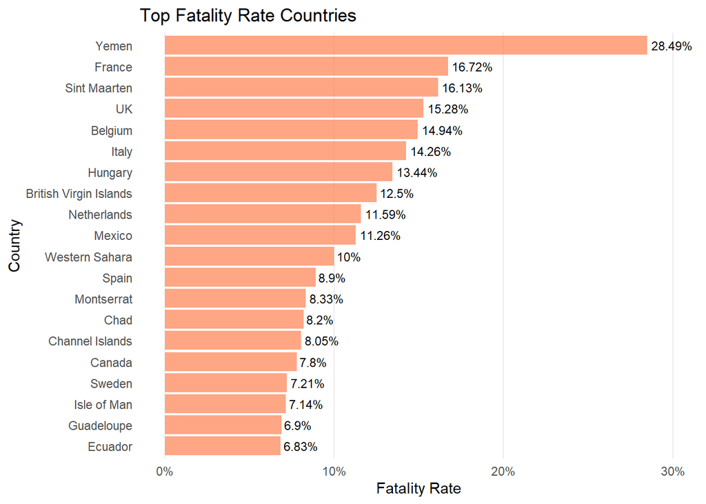

Untuk menghasilkan visualisasi seperti di atas kita akan menggunakan data `world_covid` dengan `country` dan `fatality_rate` sebagai variable untuk membuat visualisasi berupa barchart. Data yang digunakan adalah seperti berikut. Karena data yang digunakan hanya nama negara (`country`) dan `fatality_rate` maka kita pilih variable tersebut dengan fungsi `select()`.

```r
data1 <- world_covid %>%
  select(country, fatality_rate)
data1
```

| country | fatality_rate |
| --- | --- |
| USA | 0.0343 |
| Brazil | 0.0360 |
| India | 0.0228 |
| Russia | 0.0163 |
| South Africa | 0.0152 |
| Mexico | 0.1126 |
| Peru | 0.0475 |
| Chile | 0.0264 |
| Spain | 0.0890 |
| UK | 0.1528 |

[output cut: 199 more lines]

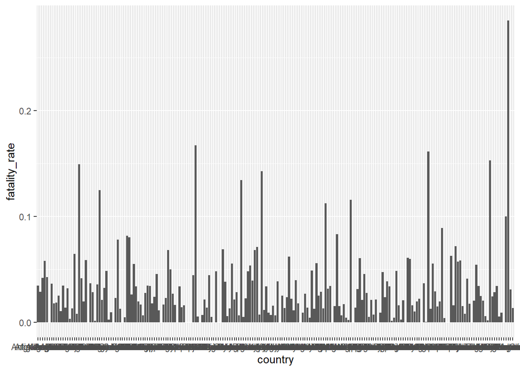

```r
ggplot(data = data1, mapping = aes(x = country, y = fatality_rate)) +
  geom_bar(stat = "identity")
```

Sulit untuk memperoleh informasi yang baik dari hasil visualisasi di atas. Kita akan coba untuk membuat label nama negara-negara lebih terlihat dengan merubah posisi label nama negara miring 90 derajat.

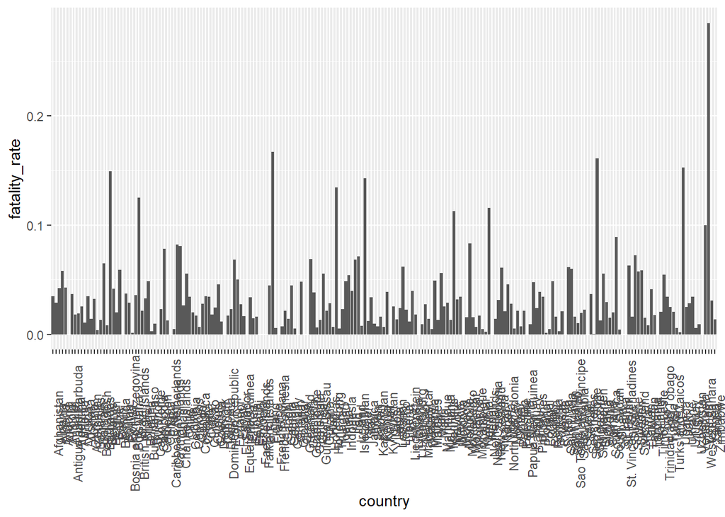

```r
# rotate x-axis label 90 deg
ggplot(data = data1, mapping = aes(x = country, y = fatality_rate)) +
  geom_bar(stat = "identity") +
  theme(axis.text.x = element_text(angle = 90))
```

Ternyata masih belum cukup terlihat dan kita belum bisa mendapatkan informasi apapun dari chart tersebut.

Kita akan coba untuk mengurutkan nama-nama negara berdasarkan *Fatality Rate*, yaitu variable `fatality_rate`. Kita gunakan fungsi `reorder(country, fatality_rate)` untuk mengurutkan barchart berdasarkan *Fatality Rate*.

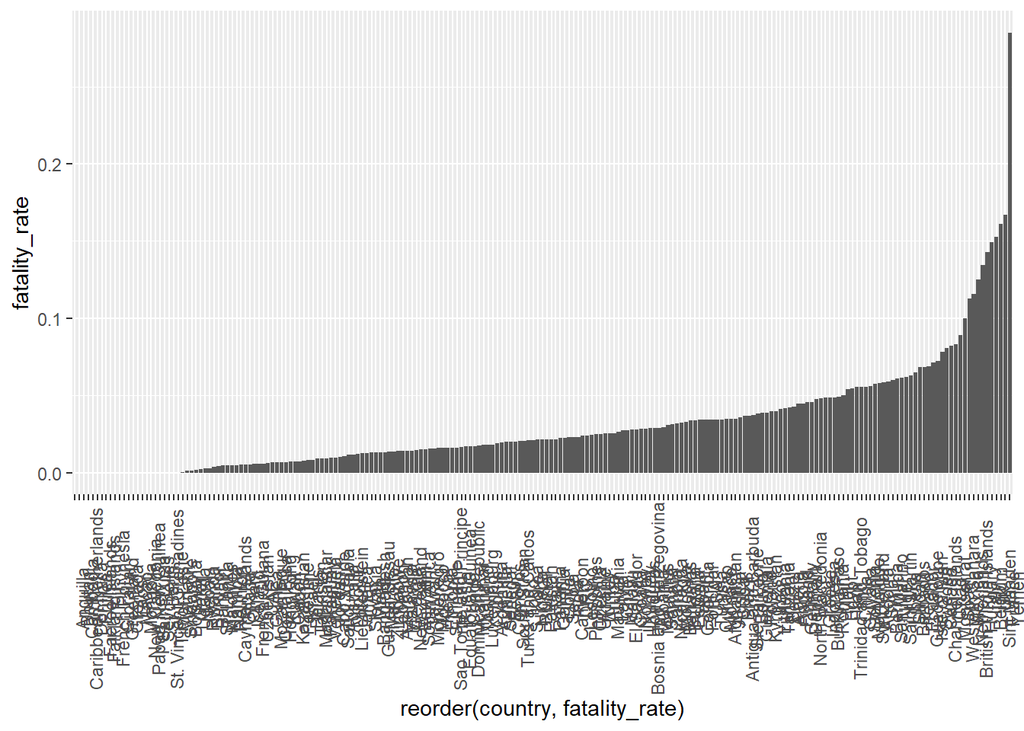

```r
# sorted barchart
ggplot(data = data1, mapping = aes(x = reorder(country, fatality_rate), y = fatality_rate)) +
  geom_bar(stat = "identity") +
  theme(axis.text.x = element_text(angle = 90))
```

Agar informasi dapat diperoleh dengan baik maka tidak semua negara akan kita tampilkan. Misalnya kita hanya perlu menampilkan daftar 20 negara berdasarkan *Fatality Rate* tertinggi. Dengan fungsi `arrange()` dan `desc()` dari package {dplyr} dan fungsi `head()` dengan `n = 20` kita akan mendapatkan 20 negara dengan *Fatality Rate* tertinggi.

```r
topn <- data1 %>%
  arrange(desc(fatality_rate)) %>%
  head(n = 20)
topn
```

|  | country | fatality_rate |
| --- | --- | --- |
| 1 | Yemen | 0.2849 |
| 2 | France | 0.1672 |
| 3 | Sint Maarten | 0.1613 |
| 4 | UK | 0.1528 |
| 5 | Belgium | 0.1494 |
| 6 | Italy | 0.1426 |
| 7 | Hungary | 0.1344 |
| 8 | British Virgin Islands | 0.1250 |
| 9 | Netherlands | 0.1159 |
| 10 | Mexico | 0.1126 |

[output cut: 10 more lines]

Selanjutnya dari data tersebut kita buat visualisasinya.

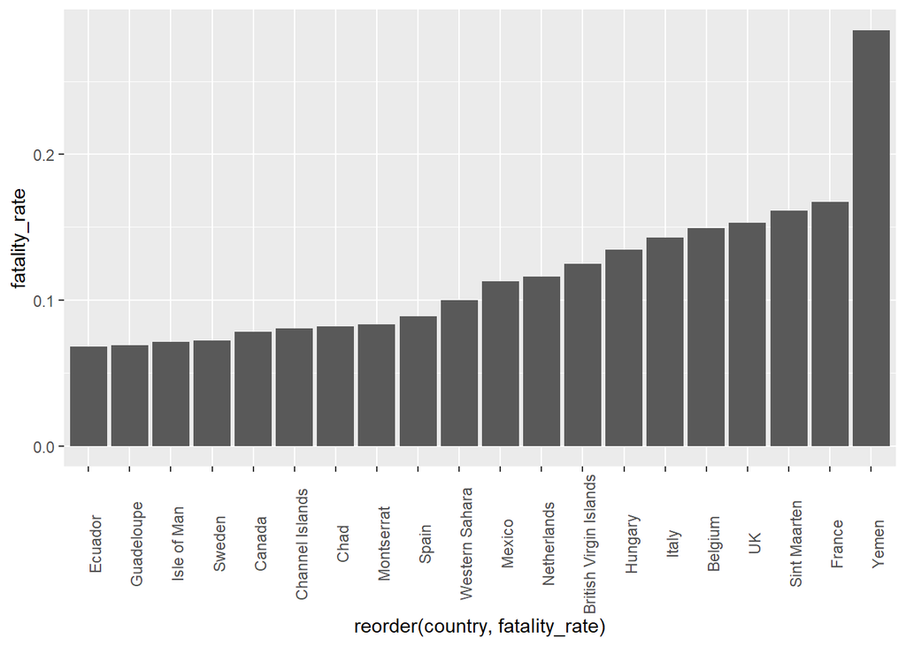

```r
# sorted barchart
ggplot(data = topn, mapping = aes(x = reorder(country, fatality_rate), y = fatality_rate)) +
  geom_bar(stat = "identity") +
  theme(axis.text.x = element_text(angle = 90))
```

Kita sudah dapat menampilkan 20 negara dengan *Fatality Rate* tertinggi. Namun tentu saja untuk publikasi ataupun dari segi estetika masih perlu ditambahkan beberapa “aksesoris”.

Selanjutnya kita akan menambahkan judul chart dan merubah judul pada masing-masing sumbu x dan y. Kita dapat menambahkan judul chart dan masing-masing sumbu, kita dapat menggunakan fungsi `labs()`. Argumen `title =` untuk judul utama, `x =` untuk judul pada sumbu x, dan `y =` untuk judul sumbu y.

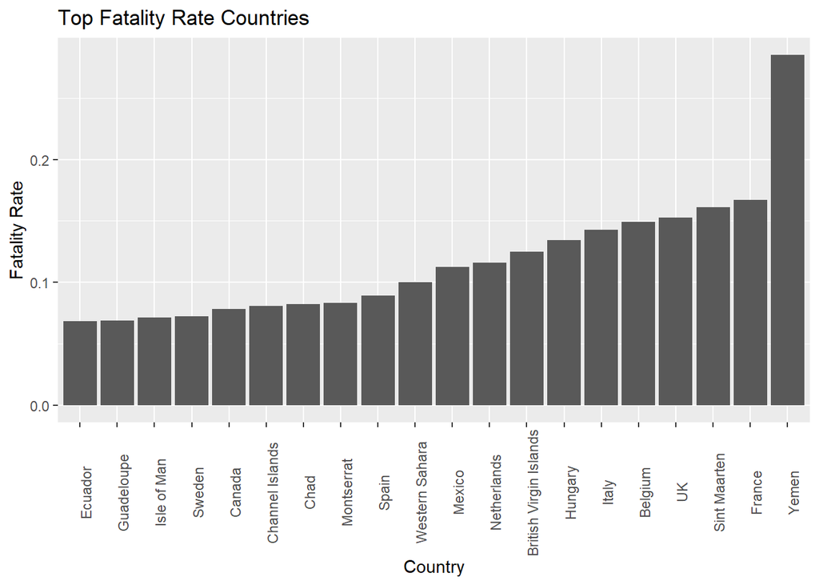

```r
ggplot(data = topn, mapping = aes(x = reorder(country, fatality_rate), y = fatality_rate)) +
  geom_bar(stat = "identity") +
  theme(axis.text.x = element_text(angle = 90)) +
  labs(title = "Top Fatality Rate Countries",
       x = "Country",
       y = "Fatality Rate")
```

Nilai *Fatality Rate* akan lebih mudah dimengerti jika ditampilkan dalam format persentase. Karena variable *Fatality Rate* ada pada sumbu y dan merupakan variable kontinu, maka kita dapat gunakan fungsi `scale_y_continuous()` dari {ggplot2}. Pada argumen `label =` kita gunakan fungsi `percent_format()` dari package {scales} agar tampilan label di sumbu *Fatality Rate* berupa persentase. Argumen `accuracy = 1` pada fungsi `percent_format()` menandakan tidak ada angka dibelakang desimal.

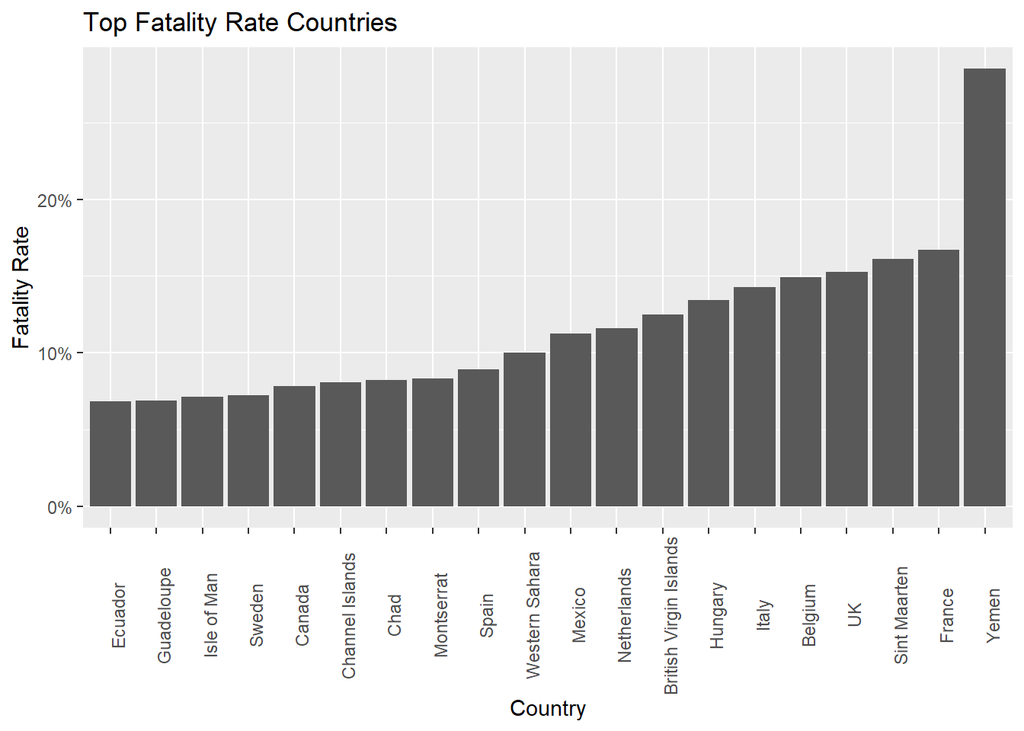

```r
# Custom axis scale
ggplot(data = topn, mapping = aes(x = reorder(country, fatality_rate), y = fatality_rate)) +
  geom_bar(stat = "identity") +
  theme(axis.text.x = element_text(angle = 90)) +
  labs(title = "Top Fatality Rate Countries",
       x = "Country",
       y = "Fatality Rate") +
  scale_y_continuous(labels = scales::percent_format(accuracy = 1))
```

Jika Anda ingin format persentase dengan satu angka di belakang desimal, gunakan `accuracy = 0.1`. Jika ingin dua angka di belakang desimal maka `accuracy = 0.01`, dan seterusnya.

Saya pribadi lebih suka ketika membuat visualisasi seperti pada kasus ini, barchart dengan label yang cukup panjang, membuatnya menjadi barchart horizontal. Karena orang awam pun akan dengan mudah mendapatkan informasi yang ingin kita sampaikan melalui visualisasi tersebut. Untuk membuat barchart horizontal, kita dapat digunakan fungsi `coord_flip()` dari package {ggplot2}. Fungsi ini akan mentransformasi sumbu-x (horizontal) menjadi sumbu-y (vertikal), dan sebaliknya.

Coba perhatikan bar negara Yaman. Pada chart sebelumnya bar negara Yaman berada pada ujung kanan sumbu-x. Dengan fungsi `coord_flip()` menjadi di ujung atas sumbu-y. Artinya `coord_flip()` mentransformasi dengan titik pojok kiri bawah sebagai titik tumpunya.

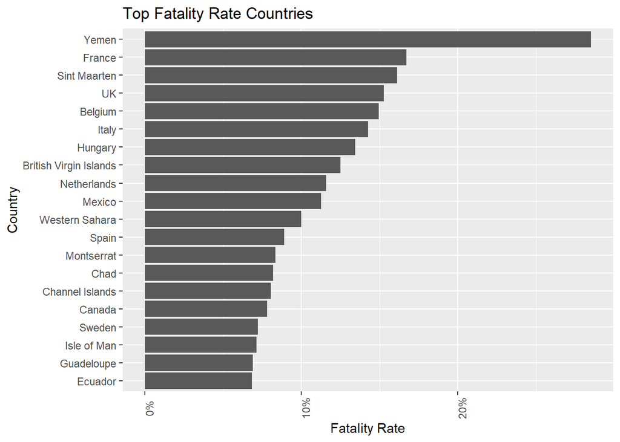

```r
# Flip barchart
ggplot(data = topn, mapping = aes(x = reorder(country, fatality_rate), y = fatality_rate)) +
  geom_bar(stat = "identity") +
  theme(axis.text.x = element_text(angle = 90)) +
  labs(title = "Top Fatality Rate Countries",
       x = "Country",
       y = "Fatality Rate") +
  scale_y_continuous(labels = scales::percent_format(accuracy = 1)) +
  coord_flip()
```

Tampilan label pada sumbu *Fatality Rate* harusnya tetap horizontal. Maka kita tidak perlu menggunakan `theme(axis.text.x = element_text(angle = 90))` lagi.

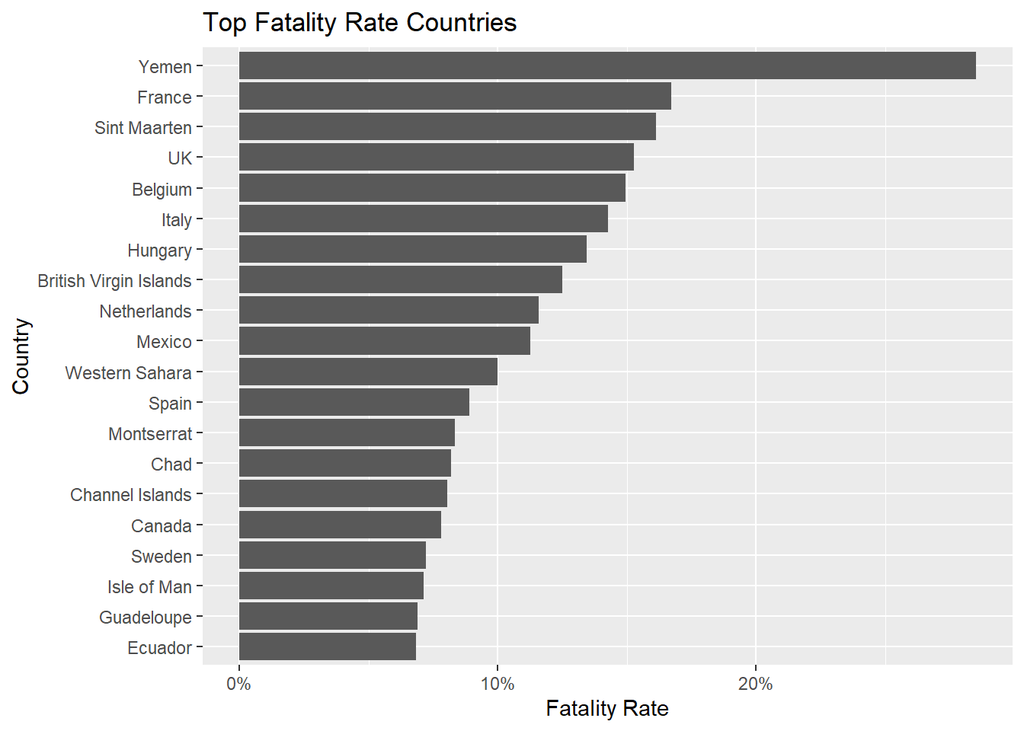

```r
# Remove text angle
ggplot(data = topn, mapping = aes(x = reorder(country, fatality_rate), y = fatality_rate)) +
  geom_bar(stat = "identity") +
  labs(title = "Top Fatality Rate Countries",
       x = "Country",
       y = "Fatality Rate") +
  scale_y_continuous(labels = scales::percent_format(accuracy = 1)) +
  coord_flip()
```

Kita dapat mengatur sebuah theme dari ggplot2 agar dapat digunakan pada chart ggplot yang kita hasilkan berikutnya tanpa harus menuliskan `+ theme_minimal()` di setiap script dengan `theme_set(theme_minimal())`. Namun pada kesempatan ini di setiap script yang menghasilkan chart dari ggplot2 akan dituliskan `+ theme_minimal()`.

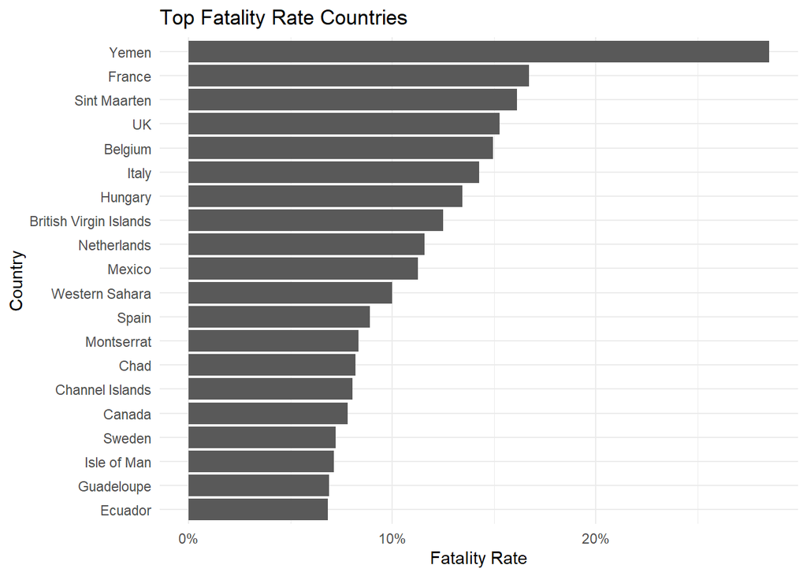

```r
# Custom theme
ggplot(data = topn, mapping = aes(x = reorder(country, fatality_rate), y = fatality_rate)) +
  geom_bar(stat = "identity") +
  labs(title = "Top Fatality Rate Countries",
       x = "Country",
       y = "Fatality Rate") +
  scale_y_continuous(labels = scales::percent_format(accuracy = 1)) +
  coord_flip() +
  theme_minimal()
```

Langkah berikutnya kita akan merubah warna bar dan grid dari chart tersebut.

Pertama kita rubah warna bar terlebih dahulu. Warna bar bisa kita rubah dengan menambahkan argumen `fill =`. Disini saya pribadi menggunakan warna `"coral"` dengan `alpha = 0.7`. Nilai `alpha` ini adalah tingkat transparansi warna atau *opacity*, antara 0 dan 1. Anda bisa memilih menggunakan warna lain seperti `"red"`, `"yellow"`, `"green"`, `"skyblue"` dan lain-lain. Bisa juga menggunakan kode warna Hex (misalnya `#E1404B`) atau RGB (misalnya `rgb(225, 64, 75, maxColorValue = 255)`). Saya pribadi sering menggunakan [color picker dari google search](https://www.google.com/search?q=color+picker) untuk memilih warna yang ingin digunakan.

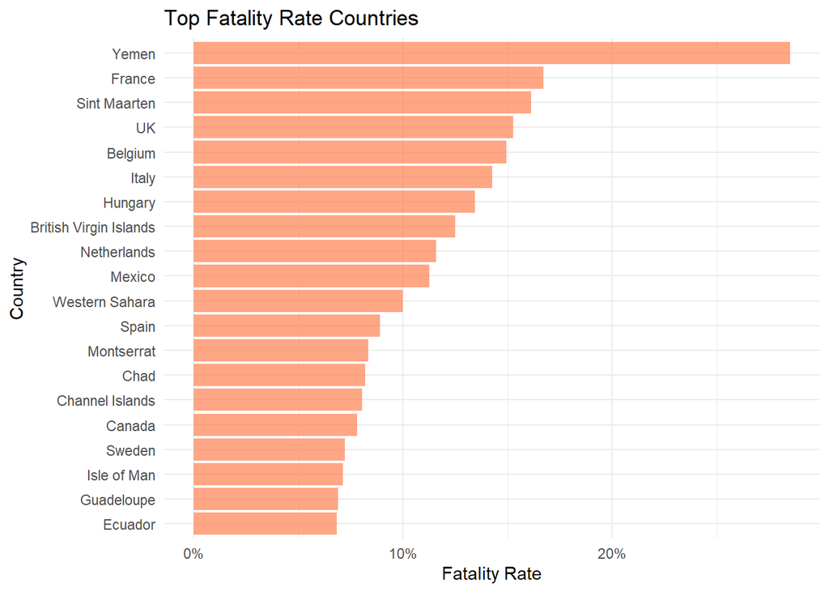

```r
# Change color & grid
ggplot(data = topn, mapping = aes(x = reorder(country, fatality_rate), y = fatality_rate)) +
  geom_bar(stat = "identity", fill = "coral", alpha = 0.7) +
  labs(title = "Top Fatality Rate Countries",
       x = "Country",
       y = "Fatality Rate") +
  scale_y_continuous(labels = scales::percent_format(accuracy = 1)) +
  coord_flip() +
  theme_minimal()
```

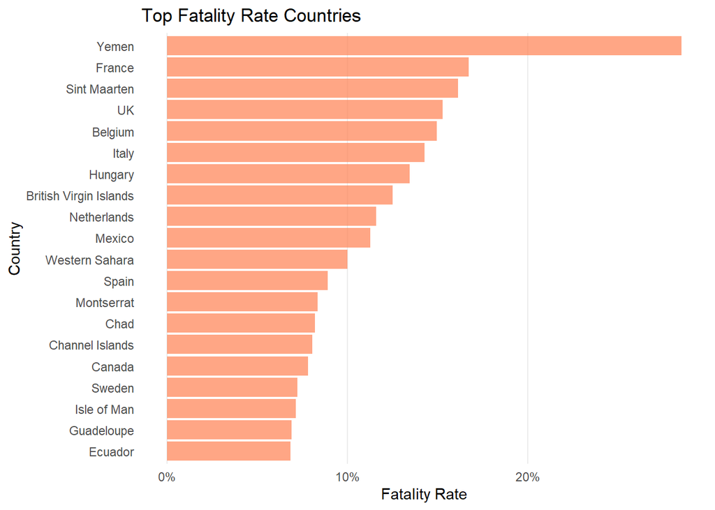

```r
# Change color & grid
ggplot(data = topn, mapping = aes(x = reorder(country, fatality_rate), y = fatality_rate)) +
  geom_bar(stat = "identity", fill = "coral", alpha = 0.7) +
  labs(title = "Top Fatality Rate Countries",
       x = "Country",
       y = "Fatality Rate") +
  scale_y_continuous(labels = scales::percent_format(accuracy = 1)) +
  coord_flip() +
  theme_minimal() +
  theme(panel.grid.major.y = element_blank(),
        panel.grid.minor.y = element_blank(),
        panel.grid.minor.x = element_blank())
```

Kita sudah membuat chart yang cukup baik. Namun saya ingin menambahkan nilai *Fatality Rate* di setiap ujung bar agar informasi yang disampaikan lebih lengkap. Kita dapat gunakan fungsi `geom_text()` atau `geom_label()`, tinggal disesuaikan dengan selera masing-masing. Karena nilai dari variable `fatality_rate` antara 0 dan 1, maka perlu dikalikan 100 untuk mendapatkan nilai persentase sebagai *text* kemudian ditambahkan tanda “%” dengan fungsi `paste0()`. Untuk menyesuaikan ukuran *text*-nya kita gunakan argumen `size =`. Semakin besar nilai `size =` maka semakin besar juga ukuran *text*. Argumen `hjust = -0.1` untuk mengatur posisi secara horizontal.

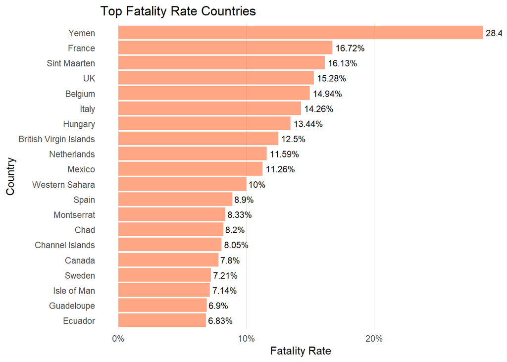

```r
# Add label & y-limit
ggplot(data = topn, mapping = aes(x = reorder(country, fatality_rate), y = fatality_rate)) +
  geom_bar(stat = "identity", fill = "coral", alpha = 0.7) +
  labs(title = "Top Fatality Rate Countries",
       x = "Country",
       y = "Fatality Rate") +
  scale_y_continuous(labels = scales::percent_format(accuracy = 1)) +
  coord_flip() +
  theme_minimal() +
  theme(panel.grid.major.y = element_blank(),
        panel.grid.minor.y = element_blank(),
        panel.grid.minor.x = element_blank()) +
  geom_text(aes(label = paste0(fatality_rate*100, "%")), size = 3, hjust = -0.1)
```

Seperti yang dilihat, ada *text* yang terpotong karena sumbu *Fatality Rate* yang kurang panjang. Kita dapat mengatur batas (limits) dari sumbu *Fatality Rate* ini dengan menambahkan argumen `limits = c(<min>, <max>)` pada fungsi `scale_y_continuous()`. Nilai `<min>` dan `<max>` adalah pangkal dan batas ujung sumbu. Karena nilai `fatality_rate` antara 0 dan 1 dan saya ingin batasnya sampai nilai 30% maka `limits = c(0, 0.30)`. Saya pilih 30% hanya agar semua *text* dari masing-masing bar tidak ada yang terpotong.

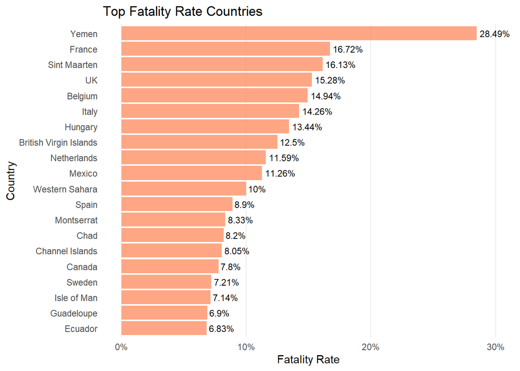

```r
# Add label & y-limit
ggplot(data = topn, mapping = aes(x = reorder(country, fatality_rate), y = fatality_rate)) +
  geom_bar(stat = "identity", fill = "coral", alpha = 0.7) +
  labs(title = "Top Fatality Rate Countries",
       x = "Country",
       y = "Fatality Rate") +
  scale_y_continuous(labels = scales::percent_format(accuracy = 1), limits = c(0, 0.30)) +
  coord_flip() +
  theme_minimal() +
  theme(panel.grid.major.y = element_blank(),
        panel.grid.minor.y = element_blank(),
        panel.grid.minor.x = element_blank()) +
  geom_text(aes(label = paste0(fatality_rate*100, "%")), size = 3, hjust = -0.1)
```

Kita juga bisa membuat visualisasi seperti di atas berdasarkan banyaknya kasus yang terjadi di suatu negara.

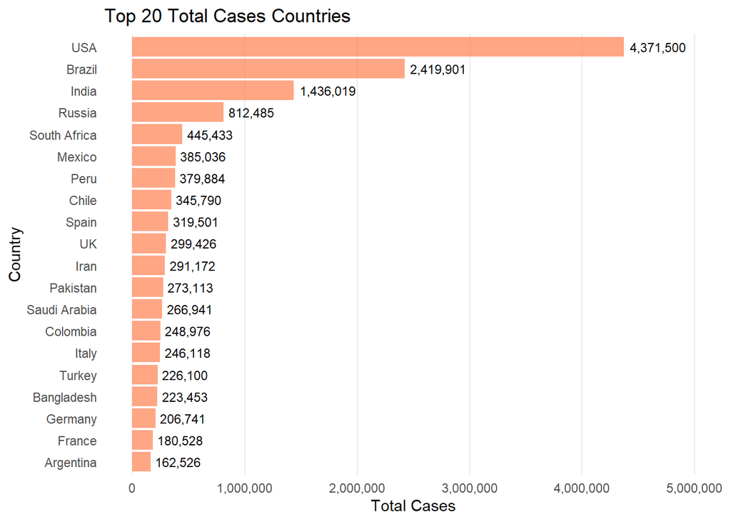

```r
# By Total Cases
## top 20 barchart
top20 <- world_covid %>%
  arrange(desc(total_cases)) %>%
  head(n = 20)

ggplot(data = top20, mapping = aes(x = reorder(country, total_cases), y = total_cases)) +
  geom_bar(stat = "identity", fill = "coral", alpha = 0.7) +
  geom_text(aes(label = formatC(total_cases, big.mark = ",", decimal.mark = ".", format = "d")), size = 3, hjust = -0.1) +
  coord_flip() +
  labs(title = "Top 20 Total Cases Countries",
       x = "Country",
       y = "Total Cases") +
  theme_minimal() +
  scale_y_continuous(labels = scales::number_format(big.mark = ","), limits = c(0, 5.0*10^6)) +
  theme(panel.grid.major.y = element_blank(),
        panel.grid.minor.y = element_blank(),
        panel.grid.minor.x = element_blank())
```

# Indonesia Amongst ASEAN

Pada visualisasi kedua ini kita akan melakukan eksplorasi data `world_covid` dengan continent Asia saja. Kemudian melihat posisi Indonesia jika dibandingkan negara Asia dan ASEAN yang lain melalui visualisasi berupa bubble chart seperti berikut ini.

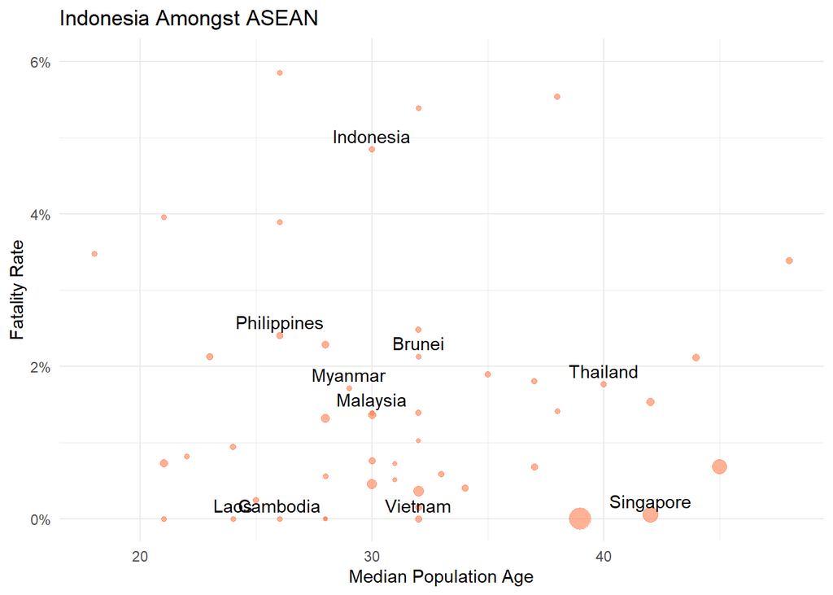

Untuk membuat bubble chart di ggplot2 kita dapat menggunakan `geom_point()`. Dasarnya adalah membuat *scatter plot* dengan `geom_point()` kemudian ukuran titiknya disesuaikan dengan nilai masing-masing. Untuk membuat *scatter plot* dibutuhkan dua variable numerik untuk menentukan koordinat x (horizontal) dan y (vertikal). Pada kasus ini kita akan menggunakan variable `med_age` yang merupakan median usia dari seluruh populasi penduduk di suatu negara sebagai sumbu x, dan variable `fatality_rate` sebagai sumbu y.

Kita buat dahulu sebuah vector character berisi nama-nama negara ASEAN dengan nama `asean_list`.

```r
asean_list <- c("Philippines",
"Indonesia",
"Malaysia",
"Singapore",
"Thailand",
"Brunei",
"Vietnam",
"Laos",
"Myanmar",
"Cambodia")
```

Selanjutnya filter data dengan continent `"Asia"` saja dan urutkan berdasarkan nilai pada variable `total_cases`. Kemudian buat sebuah variable bernama `label_negara`. Variable ini berisi nama negara jika negara pada variable `country` ada diantara nama negara ASEAN (`asean_list`). Jika tidak, maka nilainya *blank*.

```r
asean <- world_covid %>%
  filter(continent == "Asia") %>%
  arrange(total_cases) %>%
  mutate(label_negara = case_when(country %in% asean_list ~ country,
                          TRUE ~ ""))
```

Setelah itu buat visualisasinya dengan x adalah `med_age` dan y adalah `fatality_rate`.

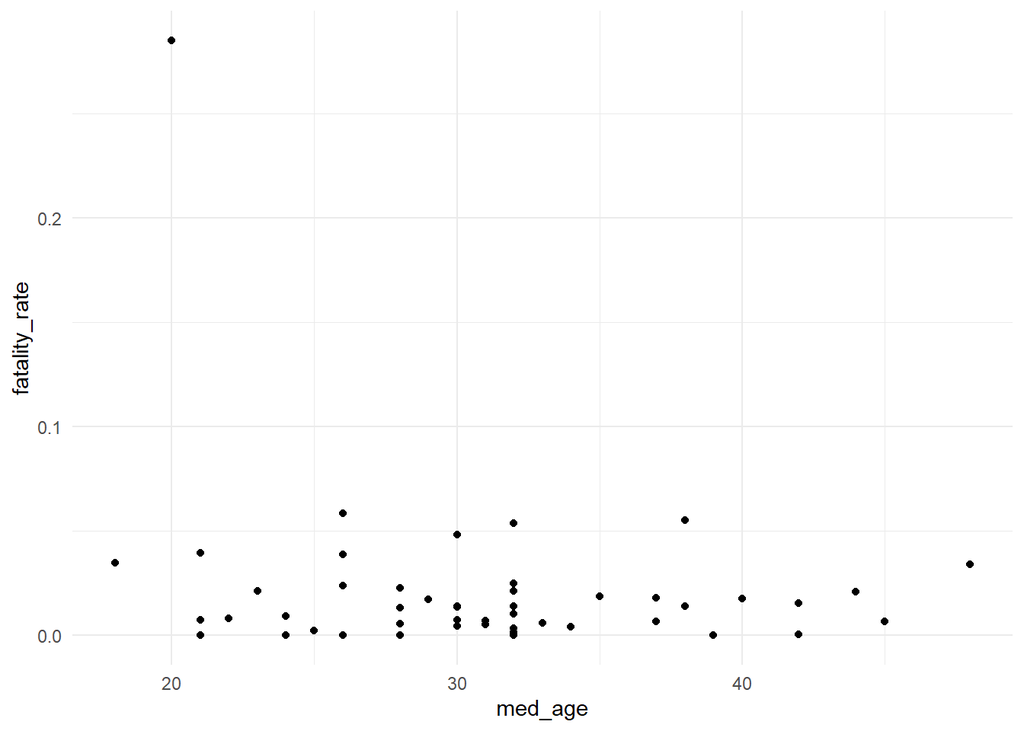

```r
# Scatter plot
ggplot(data = asean, mapping = aes(x = med_age, y = fatality_rate)) +
  geom_point() +
  theme_minimal()
```

Belum banyak informasi yang bisa kita peroleh dari visualisasi tersebut kecuali satu titik yang berada paling atas yang jauh dari titik yang lain.

Kita atur tingkat transparansi dari masing-masing titik tersebut agar dapat terlihat apakah ada titik yang bertumpuk dengan `alpha = 0.5`.

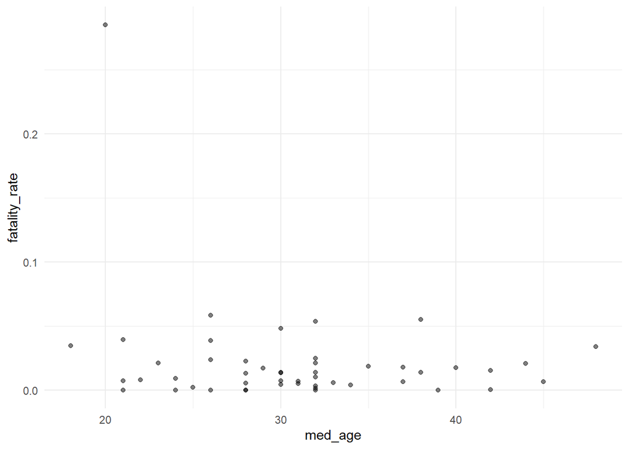

```r
# Point opacity
ggplot(data = asean, mapping = aes(x = med_age, y = fatality_rate)) +
  geom_point(alpha = 0.5) +
  theme_minimal()
```

Ternyata ada beberapa negara yang nilai `med_age` dan `fatality_rate`-nya hampir sama. Terlihat dari adanya titik yang lebih tebal warnanya dibanding titik lain karena titiknya bertumpuk.

Berikutnya kita atur ukuran dari masing-masing titik sesuai dengan nilai kepadatan penduduk per Km<sup>2</sup> pada negara tersebut, yaitu variable `denisty_km2`. Karena nilai yang akan kita gunakan adalah sebuah variable maka kita harus menuliskannya dalam sebuah mapping `aes()`.

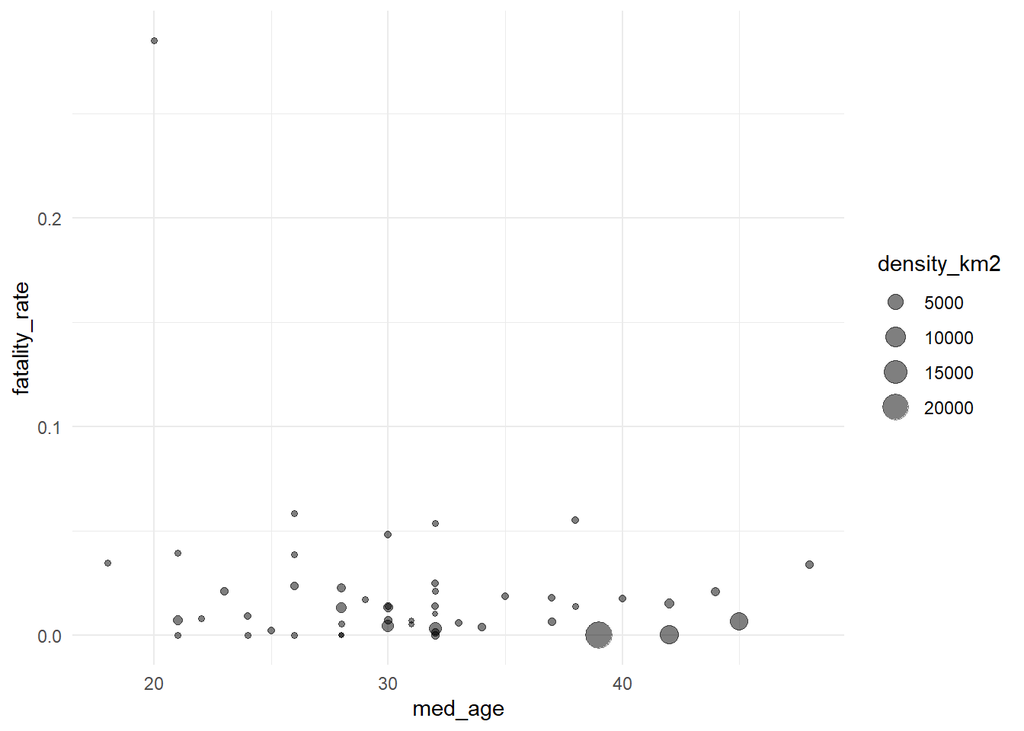

```r
# Bubble chart size
ggplot(data = asean, mapping = aes(x = med_age, y = fatality_rate)) +
  geom_point(aes(size = density_km2), alpha = 0.5) +
  theme_minimal()
```

Kita juga bisa merubah warna masing-masing titik dengan warna tertentu atau berdasarkan suatu variable dengan menambahkan `color = "coral"` misalnya, di luar `aes()`. Jika warna yang akan digunakan berdasarkan suatu variable dari data, maka argumen `color = <variable>` diletakkan di dalam `aes()`. Selain itu Anda juga bisa membuang legend dari grafik tersebut menggunakan `theme(legend.position = "none")`.

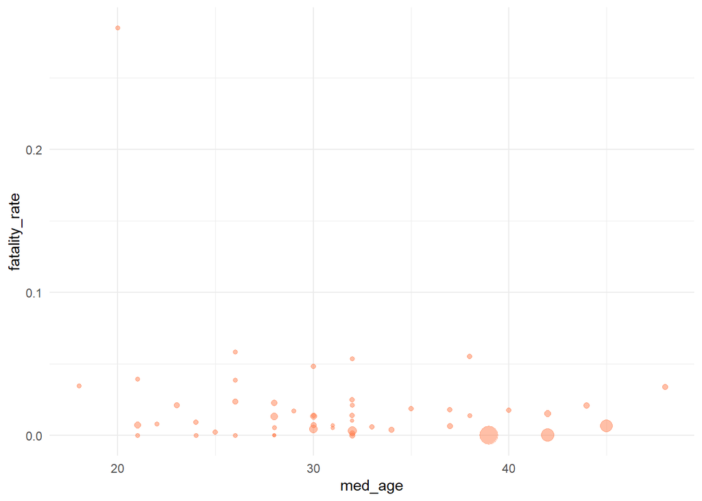

```r
# Buble chart color
ggplot(data = asean, mapping = aes(x = med_age, y = fatality_rate)) +
  geom_point(aes(size = density_km2), color = "coral", alpha = 0.5) +
  theme_minimal() +
  theme(legend.position = "none")
```

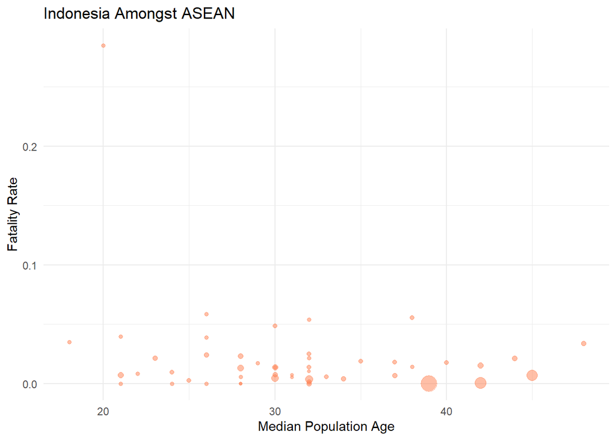

```r
# Custom title & axis title
ggplot(data = asean, mapping = aes(x = med_age, y = fatality_rate)) +
  geom_point(aes(size = density_km2), color = "coral", alpha = 0.5) +
  theme_minimal() +
  theme(legend.position = "none") +
  labs(title = "Indonesia Amongst ASEAN",
       x = "Median Population Age",
       y = "Fatality Rate")
```

Ganti format teks pada sumbu *Fatality Rate* (vertikal) menjadi persentase. Gunakan fungsi `scale_y_continuous()` seperti pada chart sebelumnya.

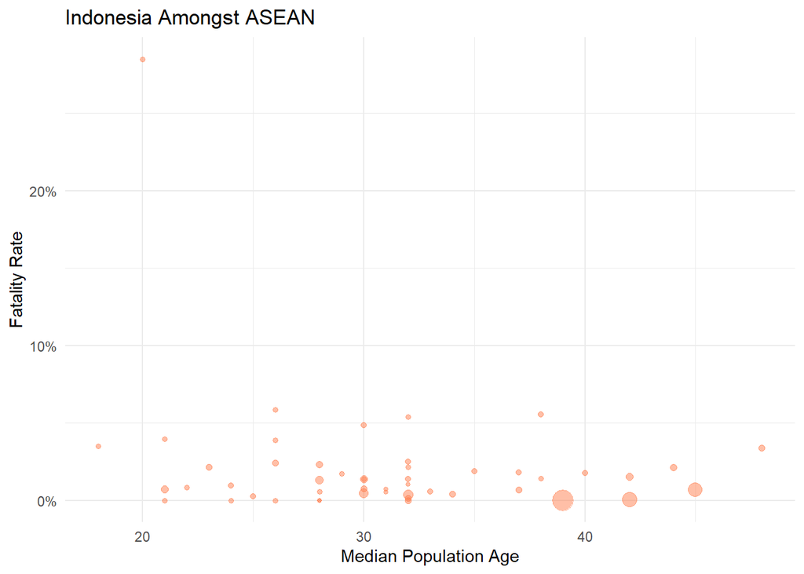

```r
# Buble chart custom axis title
ggplot(data = asean, mapping = aes(x = med_age, y = fatality_rate)) +
  geom_point(aes(size = density_km2), color = "coral", alpha = 0.5) +
  theme_minimal() +
  theme(legend.position = "none") +
  labs(title = "Indonesia Amongst ASEAN",
       x = "Median Population Age",
       y = "Fatality Rate") +
  scale_y_continuous(labels = scales::percent_format(accuracy = 1))
```

Tambahkan label nama negara pada variable `label_negara` dengan menggunakan `geom_text(aes(label = label_negara))`.

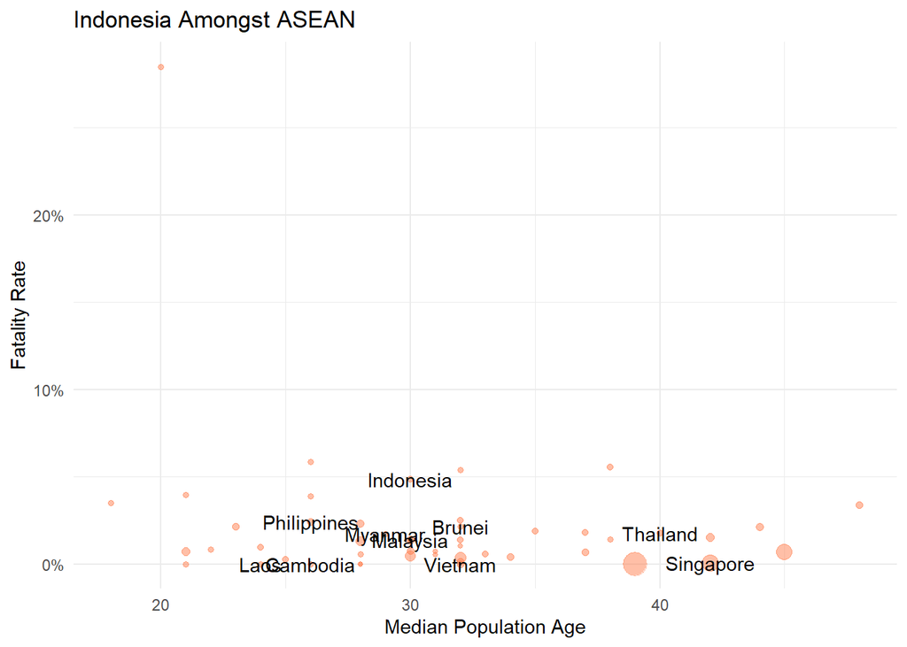

```r
# Buble chart add label
ggplot(data = asean, mapping = aes(x = med_age, y = fatality_rate)) +
  geom_point(aes(size = density_km2), color = "coral", alpha = 0.5) +
  theme_minimal() +
  theme(legend.position = "none") +
  labs(title = "Indonesia Amongst ASEAN",
       x = "Median Population Age",
       y = "Fatality Rate") +
  scale_y_continuous(labels = scales::percent_format(accuracy = 1)) +
  geom_text(aes(label = label_negara))
```

Karena fokus kita adalah Indonesia diantara negara-negara ASEAN, maka Yaman/Yemen dapat kita sisihkan dengan memotong nilai *Fatality Rate* pada grafik dengan menambahkan `limits = c(0, 0.06)`. Kemudian nama negara sedikit digeser ke atas dari titiknya dengan menggunakan argumen `vjust = -0.5`.

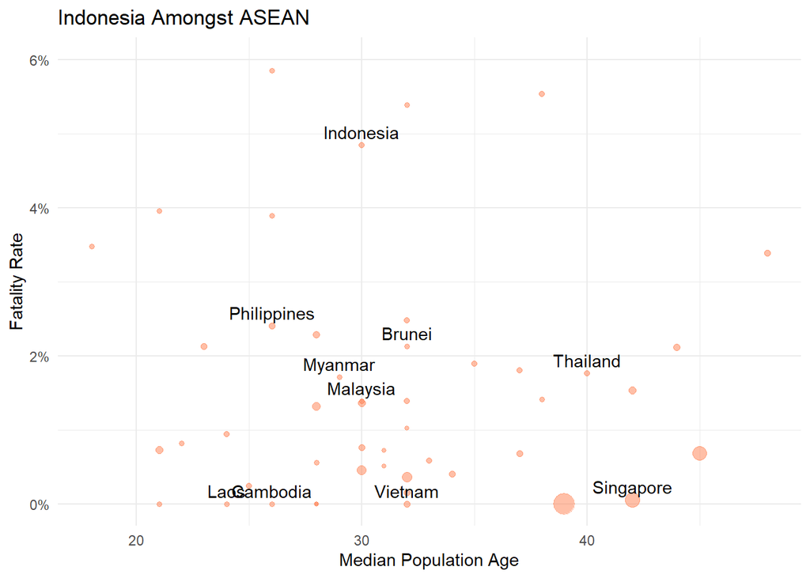

```r
# Buble chart custom label position
ggplot(data = asean, mapping = aes(x = med_age, y = fatality_rate)) +
  geom_point(aes(size = density_km2), color = "coral", alpha = 0.5) +
  theme_minimal() +
  theme(legend.position = "none") +
  labs(title = "Indonesia Amongst ASEAN",
       x = "Median Population Age",
       y = "Fatality Rate") +
  scale_y_continuous(labels = scales::percent_format(accuracy = 1), limits = c(0, 0.06)) +
  geom_text(aes(label = label_negara), vjust = -0.5)
```

# Indonesia Daily Cases Trend

Terakhir, kita akan membuat chart yang dapat menunjukkan pola penambahan kasus harian di Indonesia. Data yang digunakan adalah data `dailynational` yg diolah dari sumber https://bnpb-inacovid19.hub.arcgis.com/ melalui [API](https://services5.arcgis.com/VS6HdKS0VfIhv8Ct/arcgis/rest/services/Statistik_Perkembangan_COVID19_Indonesia/FeatureServer/0/query?where=1%3D1&outFields=*&outSR=4326&f=json).

Kita import kemudian lihat struktur dan beberapa baris pertama dari data tersebut.

```r
dailynational <- read.csv("../data-raw/dailynational.csv", header = TRUE, stringsAsFactors = FALSE)
dailynational$dates <- as.Date(dailynational$dates)
str(dailynational)
```

```
## 'data.frame':    147 obs. of  19 variables:
##  $ dates                      : Date, format: "2020-03-02" "2020-03-03" ...
##  $ total_cases                : int  2 2 2 2 4 4 6 19 27 34 ...
##  $ recovered                  : int  0 0 0 0 0 0 0 0 2 2 ...
##  $ deaths                     : int  0 0 0 0 0 0 0 0 0 1 ...
##  $ treated                    : int  2 2 2 2 4 4 6 19 25 31 ...
##  $ daily_cases                : int  2 0 0 0 2 0 2 13 8 7 ...
##  $ daily_recovered            : int  0 0 0 0 0 0 0 0 2 0 ...
##  $ daily_deaths               : int  0 0 0 0 0 0 0 0 0 1 ...
##  $ daily_treated              : int  2 0 0 0 2 0 2 13 6 6 ...
##  $ pct_recovered              : num  0 0 0 0 0 ...
##  $ pct_deaths                 : num  0 0 0 0 0 ...
##  $ pct_treated                : num  100 100 100 100 100 ...
##  $ examined_specimen          : int  NA NA NA NA NA NA NA NA NA NA ...
##  $ total_examined_specimen    : int  339 341 372 388 450 454 483 543 694 793 ...
##  $ negative                   : int  335 337 356 371 422 422 445 487 648 744 ...
##  $ daily_new_specimen         : int  NA NA NA NA NA NA NA NA NA NA ...
##  $ kasus_diperiksa_baru_harian: int  NA 2 31 16 62 4 29 60 151 99 ...
##  $ pdp                        : int  NA NA NA NA NA NA NA NA NA NA ...
##  $ odp                        : int  NA NA NA NA NA NA NA NA NA NA ...
```

```r
head(dailynational, n = 10)
```

|  | dates | total_cases | recovered | deaths | treated | daily_cases | daily_recovered | daily_deaths | daily_treated | pct_recovered | pct_deaths | pct_treated | examined_specimen | total_examined_specimen | negative | daily_new_specimen | kasus_diperiksa_baru_harian | pdp | odp |
| --- | --- | --- | --- | --- | --- | --- | --- | --- | --- | --- | --- | --- | --- | --- | --- | --- | --- | --- | --- |
| 1 | 2020-03-02 | 2 | 0 | 0 | 2 | 2 | 0 | 0 | 2 | 0.000000 | 0.000000 | 100.00000 | NA | 339 | 335 | NA | NA | NA | NA |
| 2 | 2020-03-03 | 2 | 0 | 0 | 2 | 0 | 0 | 0 | 0 | 0.000000 | 0.000000 | 100.00000 | NA | 341 | 337 | NA | 2 | NA | NA |
| 3 | 2020-03-04 | 2 | 0 | 0 | 2 | 0 | 0 | 0 | 0 | 0.000000 | 0.000000 | 100.00000 | NA | 372 | 356 | NA | 31 | NA | NA |
| 4 | 2020-03-05 | 2 | 0 | 0 | 2 | 0 | 0 | 0 | 0 | 0.000000 | 0.000000 | 100.00000 | NA | 388 | 371 | NA | 16 | NA | NA |
| 5 | 2020-03-06 | 4 | 0 | 0 | 4 | 2 | 0 | 0 | 2 | 0.000000 | 0.000000 | 100.00000 | NA | 450 | 422 | NA | 62 | NA | NA |
| 6 | 2020-03-07 | 4 | 0 | 0 | 4 | 0 | 0 | 0 | 0 | 0.000000 | 0.000000 | 100.00000 | NA | 454 | 422 | NA | 4 | NA | NA |
| 7 | 2020-03-08 | 6 | 0 | 0 | 6 | 2 | 0 | 0 | 2 | 0.000000 | 0.000000 | 100.00000 | NA | 483 | 445 | NA | 29 | NA | NA |
| 8 | 2020-03-09 | 19 | 0 | 0 | 19 | 13 | 0 | 0 | 13 | 0.000000 | 0.000000 | 100.00000 | NA | 543 | 487 | NA | 60 | NA | NA |
| 9 | 2020-03-10 | 27 | 2 | 0 | 25 | 8 | 2 | 0 | 6 | 7.407407 | 0.000000 | 92.59259 | NA | 694 | 648 | NA | 151 | NA | NA |
| 10 | 2020-03-11 | 34 | 2 | 1 | 31 | 7 | 0 | 1 | 6 | 5.882353 | 2.941176 | 91.17647 | NA | 793 | 744 | NA | 99 | NA | NA |

Karena data yang dimiliki adalah laporan harian, terdapat tanggal, dan kita ingin mengetahui pola kasus harian, maka akan lebih tepat jika kita gunakan chart garis (*line chart*) yang biasa digunakan untuk visualisasi data deret waktu atau *time series*.

Kita akan menampilkan kasus penambahan baru harian (`daily_cases`), sembuh harian (`daily_recovered`), menginggal harian (`daily_deaths`) dan sebuah trend untuk kasus penambahan baru harian pada *line chart* tersebut seperti berikut ini.

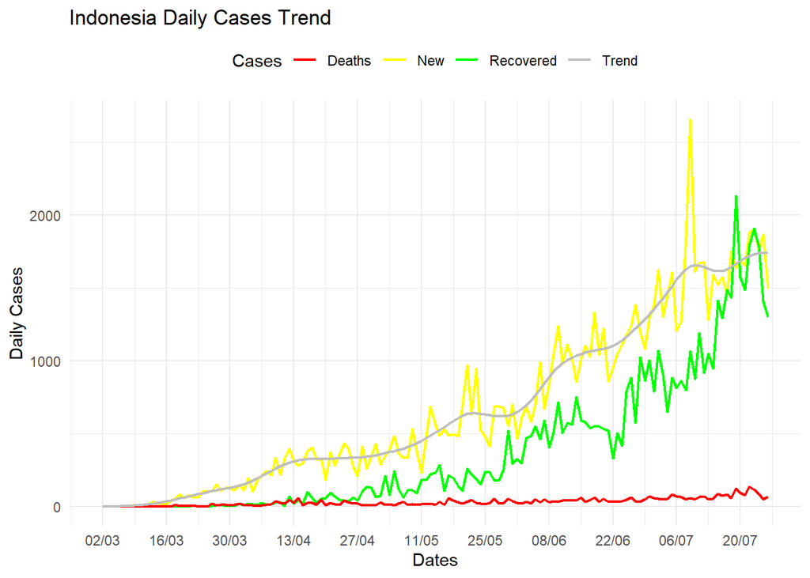

Yang perlu kita ingat adalah struktur data yang kita gunakan seperti berikut.

```r
dailynational %>%
  select(dates, daily_cases, daily_recovered, daily_deaths) %>%
  head(n = 10)
```

|  | dates | daily_cases | daily_recovered | daily_deaths |
| --- | --- | --- | --- | --- |
| 1 | 2020-03-02 | 2 | 0 | 0 |
| 2 | 2020-03-03 | 0 | 0 | 0 |
| 3 | 2020-03-04 | 0 | 0 | 0 |
| 4 | 2020-03-05 | 0 | 0 | 0 |
| 5 | 2020-03-06 | 2 | 0 | 0 |
| 6 | 2020-03-07 | 0 | 0 | 0 |
| 7 | 2020-03-08 | 2 | 0 | 0 |
| 8 | 2020-03-09 | 13 | 0 | 0 |
| 9 | 2020-03-10 | 8 | 2 | 0 |
| 10 | 2020-03-11 | 7 | 0 | 1 |

Dengan `ggplot2` kita akan membuat sebuah *line chart* untuk masing-masing variable tersebut terhadap variable tanggal. Karena yang menjadi sumbu-x ( *horizontal* ) adalah variable tanggal untuk semua variable kasus, maka `aes(x = dates)` dapat kita tuliskan satu kali saja di argumen `mapping` pada fungsi `ggplot()`, sedangkan masing-masing variable kasus kita tuliskan di masing-masing `geom_line()`.

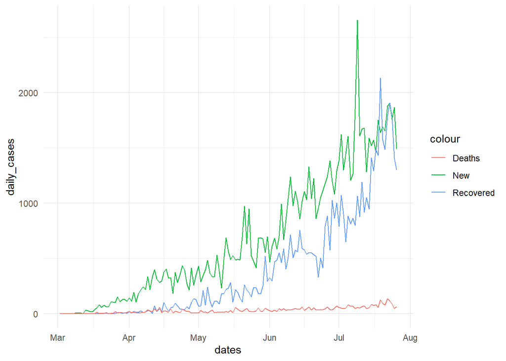

```r
ggplot(data = dailynational, mapping = aes(x = dates)) +
  geom_line(aes(y = daily_cases, color = "New")) +
  geom_line(aes(y = daily_recovered, color = "Recovered")) +
  geom_line(aes(y = daily_deaths, color = "Deaths")) +
  theme_minimal()
```

Selanjutnya kita akan menyesuaikan warna untuk masing-masing kasus agar lebih cocok terhadap jenis kasusnya. Misalnya untuk kasus `New` kita gunakan warna kuning (`yellow`), `Recovered` dengan warna hijau (`green`), dan `Deaths` dengan warna merah (`red`). Tebalnya garis juga akan kita sesuaikan sehingga lebih tebal.

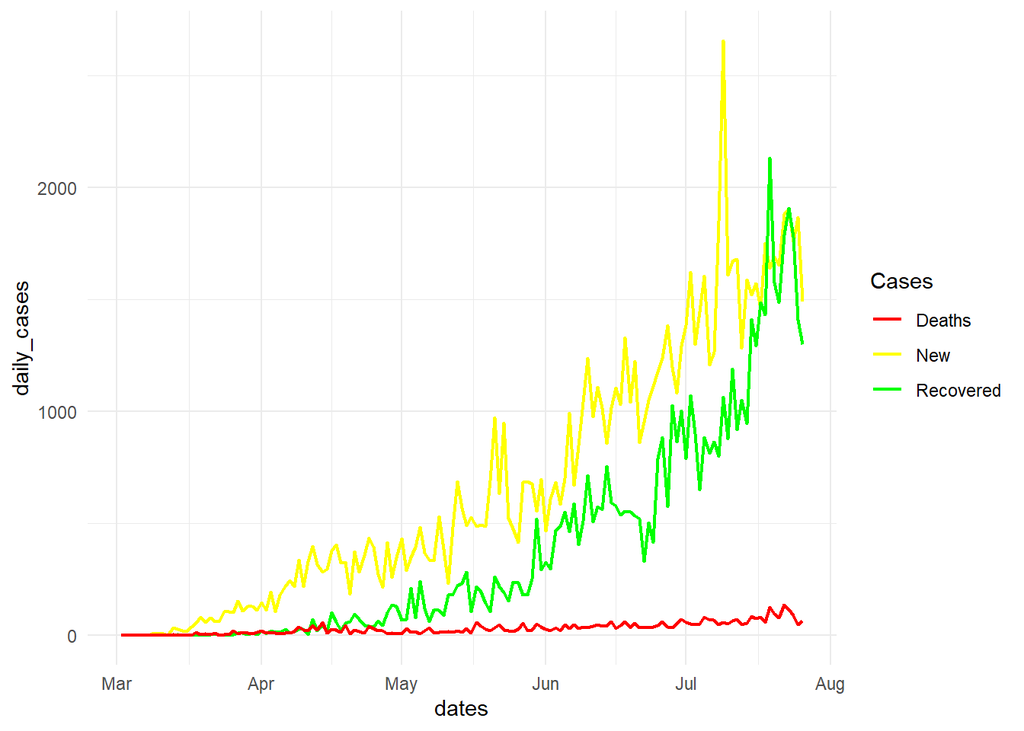

```r
# Change color & line size
ggplot(data = dailynational, mapping = aes(x = dates)) +
  geom_line(aes(y = daily_cases, color = "New"), size = 0.8) +
  geom_line(aes(y = daily_recovered, color = "Recovered"), size = 0.8) +
  geom_line(aes(y = daily_deaths, color = "Deaths"), size = 0.8) +
  theme_minimal() +
  scale_color_manual(name = "Cases", # judul legend
                     values = c("New" = "yellow",
                                "Recovered" = "green",
                                "Deaths" = "red"))
```

Agar visualisasinya lebih baik selanjutnya kita tambahkan judul chart dan judul masing-masing sumbu.

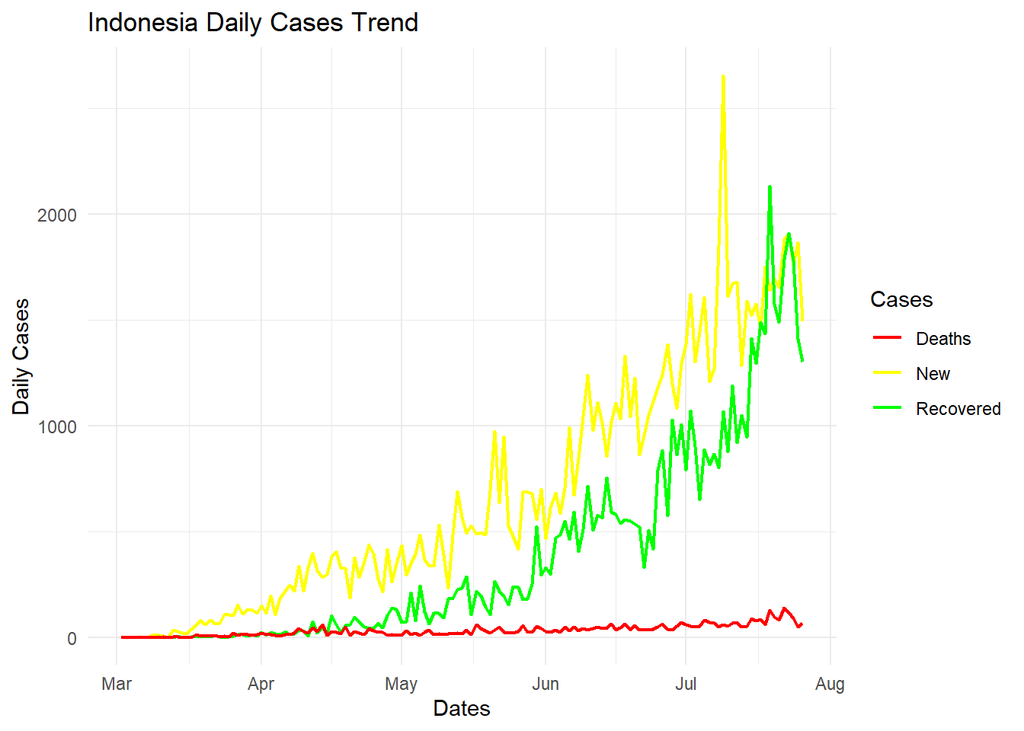

```r
# Add title and axis title
ggplot(data = dailynational, mapping = aes(x = dates)) +
  geom_line(aes(y = daily_cases, color = "New"), size = 0.8) +
  geom_line(aes(y = daily_recovered, color = "Recovered"), size = 0.8) +
  geom_line(aes(y = daily_deaths, color = "Deaths"), size = 0.8) +
  theme_minimal() +
  scale_color_manual(name = "Cases", # judul legend
                     values = c("New" = "yellow",
                                "Recovered" = "green",
                                "Deaths" = "red")) +
  labs(title = "Indonesia Daily Cases Trend",
       x = "Dates",
       y = "Daily Cases")
```

Berikutnya kita rubah format label pada sumbu x (Dates) agar kita bisa mengetahui tanggalnya. Format yang akan digunakan adalah “dd/mm” karena tahunnya sama, yaitu 2020, maka tidak perlu ditampilkan. Karena nilai pada sumbu x adalah tanggal, maka kita dapat gunakan fungsi `scale_x_date()`. Kemudian argumen `date_breaks = "2 weeks"` artinya antar tanggal yang ditampilkan (*major ticks*) berjarak 2 minggu, sehingga *minor ticks* adalah 1 minggu.

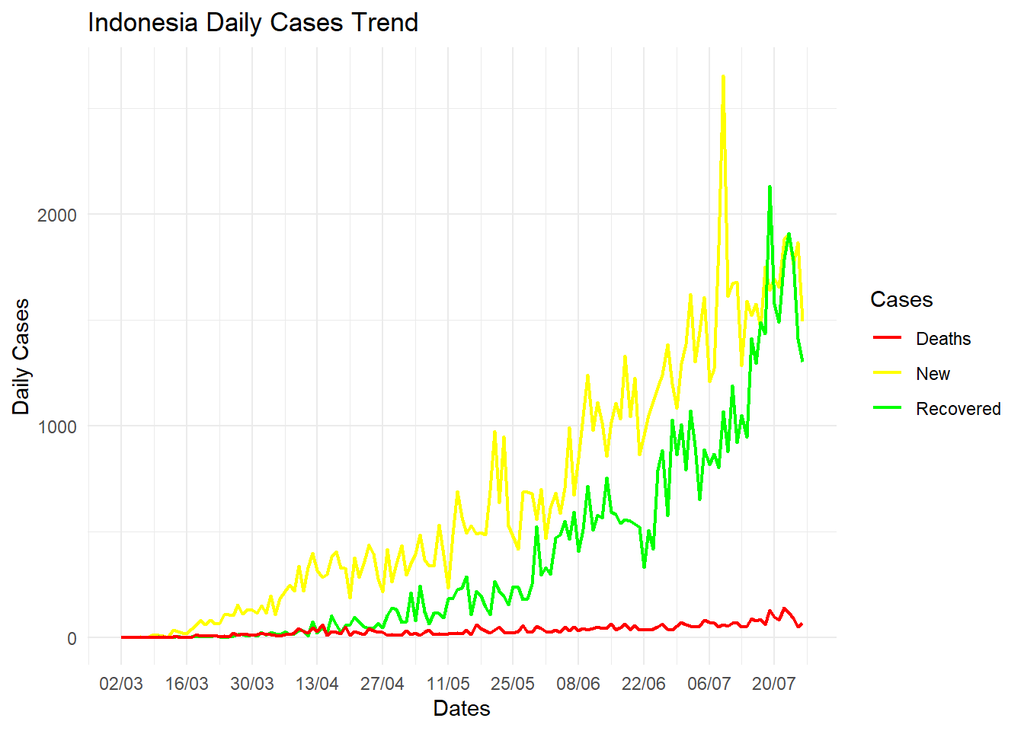

```r
# Change x-axis format
ggplot(data = dailynational, mapping = aes(x = dates)) +
  geom_line(aes(y = daily_cases, color = "New"), size = 0.8) +
  geom_line(aes(y = daily_recovered, color = "Recovered"), size = 0.8) +
  geom_line(aes(y = daily_deaths, color = "Deaths"), size = 0.8) +
  theme_minimal() +
  scale_color_manual(name = "Cases", # judul legend
                     values = c("New" = "yellow",
                                "Recovered" = "green",
                                "Deaths" = "red")) +
  labs(title = "Indonesia Daily Cases Trend",
       x = "Dates",
       y = "Daily Cases") +
  scale_x_date(date_breaks = "2 weeks", date_labels = "%d/%m")
```

Selanjutnya kita akan menambahkan sebuah garis trend pada chart di atas yang menunjukkan pola penambahan kasus baru harian di Indonesia. Yang kita butuhkan adalah data tanggal (`dates`) dan jumlah kasus penambahan harian (`daily_cases`). Untuk membuat data trend-nya kita gunakan *Kernel Smoothing* dengan fungsi `ksmooth` dari package {stats} yang sudah menjadi bagian dari base R ketika kita install R. Tidak ada alasan khusus yang saya gunakan sebagai pedoman ketika memilih fungsi ini. Ada beberapa metode lain yang dapat digunakan untuk membuat trend seperti yang ditulis di [artikel ini](https://www.displayr.com/smoothing-time-series-data/?utm_medium=Feed&utm_source=Syndication).

```r
# Add trend line
ks <- ksmooth(x = dailynational$dates,
              y = dailynational$daily_cases,
              kernel = "normal",
              bandwidth = 10,
              x.points = dailynational$dates)
dailynational$daily_trend <- ks$y
```

Kita tambahkan data trend tersebut menggunakan `geom_line()`.

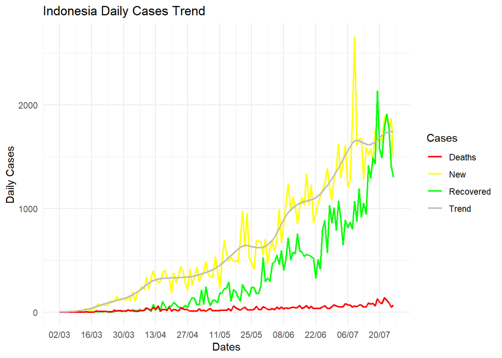

```r
ggplot(data = dailynational, mapping = aes(x = dates)) +
  geom_line(aes(y = daily_cases, color = "New"), size = 0.8) +
  geom_line(aes(y = daily_recovered, color = "Recovered"), size = 0.8) +
  geom_line(aes(y = daily_deaths, color = "Deaths"), size = 0.8) +
  theme_minimal() +
  scale_color_manual(name = "Cases",
                     values = c("New" = "yellow",
                                "Recovered" = "green",
                                "Deaths" = "red",
                                "Trend" = "grey")) +
  labs(title = "Indonesia Daily Cases Trend",
       x = "Dates",
       y = "Daily Cases") +
  scale_x_date(date_breaks = "2 weeks", date_labels = "%d/%m") +
  geom_line(aes(y = daily_trend, color = "Trend"), size = 0.8)
```

Untuk visualisasi ini saya pribadi lebih suka jika legend-nya diletakan di atas chart. Karena itu saya tambahkan fungsi `theme(legend.position = "top")`.

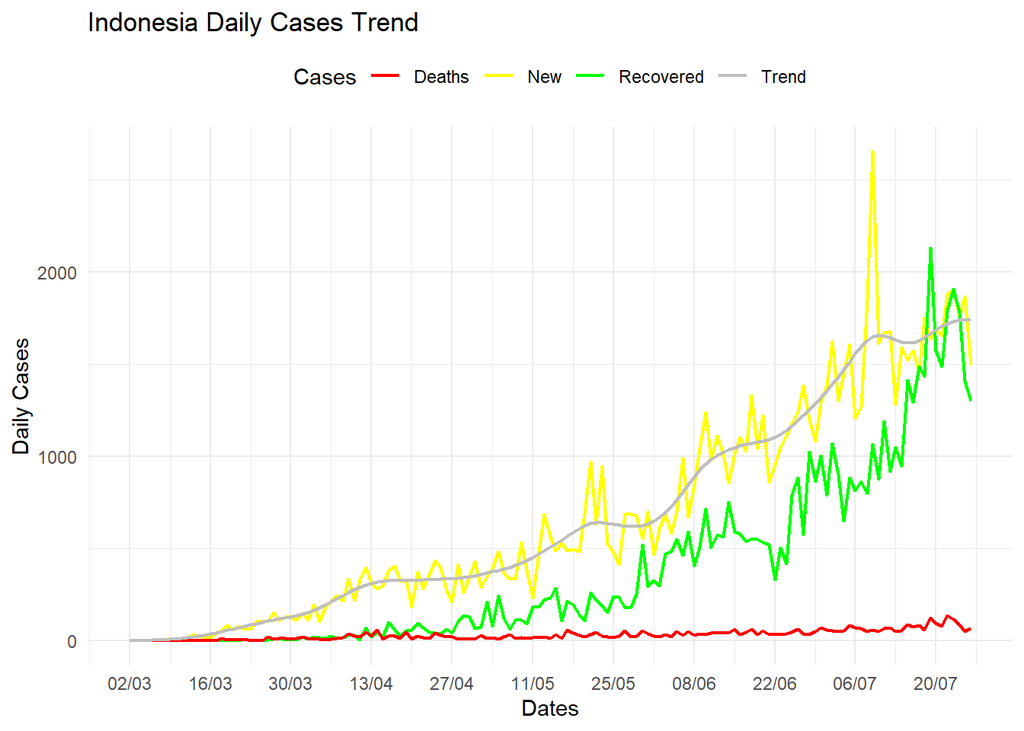

```r
# Custom legend & position
ggplot(data = dailynational, mapping = aes(x = dates)) +
  geom_line(aes(y = daily_cases, color = "New"), size = 0.8) +
  geom_line(aes(y = daily_recovered, color = "Recovered"), size = 0.8) +
  geom_line(aes(y = daily_deaths, color = "Deaths"), size = 0.8) +
  theme_minimal() +
  scale_color_manual(name = "Cases",
                     values = c("New" = "yellow",
                                "Recovered" = "green",
                                "Deaths" = "red",
                                "Trend" = "grey")) +
  labs(title = "Indonesia Daily Cases Trend",
       x = "Dates",
       y = "Daily Cases") +
  scale_x_date(date_breaks = "2 weeks", date_labels = "%d/%m") +
  geom_line(aes(y = daily_trend, color = "Trend"), size = 0.8) +
  theme(legend.position = "top")
```